# Trabajo Final

```r
library(rmdformats)
```

# **Introducción**

La desigualdad de género es un problema latente aún en pleno siglo XXI. El informe “The Global Gender Gap Index 2020”, de World Economic Forum, reveló que aún faltarían 199.5 años para que el mundo sea una sociedad más paritaria. Asimismo, se puede evidenciar que la búsqueda por cerrar estas brechas se da de manera homogénea en el globo terráqueo, y por tanto, muchos grupos de mujeres -en la actualidad- aún se ven en situaciones de desventaja a comparación de los hombres.

Sin duda, existen muchos factores que se relacionan con la desigualdad de género, por ejemplo: factores culturales o religiosos, económicos o sociales; empero, en el presente trabajo queremos centrarnos en la investigación de factores políticos. Por ello, buscamos averiguar la relación entre desigualdad de género y regímenes políticos no democráticos. En ese sentido, nuestra idea es que aquellos países que poseen una política inestable (constantes crisis políticas, conflictos armados, etc.), con bajos niveles de desarrollo humano y poca cultura democrática van a tender a relegar y subordinar a las mujeres en sus sociedades. En consiguiente, podríamos decir que aquellas sociedades con carácteres autoritarios y bajos niveles desarrollo (ejem: países de Medio Oriente y África) no tienen como prioridad próxima las disparidades entre los ciudadanos y ciudadanas de sus Estados.

La relevancia de la investigación sobre esta problemática radica en la urgencia de identificar condiciones de riesgo sobre los derechos de las mujeres, los cuales aún no están garantizados en todos los países del mundo. De esta manera, consideramos que determinados contextos y tipos de gobiernos son más propensos a desarrollar actitudes y prácticas que atenten los derechos y socaven los avances de igualdad de género en el mundo. Por ello, es importante identificar qué escenarios políticos dan pie a una mayor vulneración para que, de esta manera, se pueda tomar consciencia y tomar las acciones necesarias para hacer frente a esta problemática.

# **Revisión de la literatura y objetivos**

Según un informe de la BBC Mundo (2016), las regiones del mundo donde se pueden evidenciar los mayores índices de desigualdad de género son las zonas de Asia Meridional, África Sub-sahariana y del Norte, Oriente Medio y América Latina y el Caribe. Empero, los niveles de este tipo de disparidad al mismo tiempo varían dependiendo del país y del tipo de Estado en el que una mujer habita. De hecho, muchos autores concuerdan que los regímenes democráticos tienden a poseer mayores grados de igualdad entre mujeres y hombres puesto que dentro de sus valores y principios se tiene muy presente el tema de la “igualdad”. Asimismo, la concepción de igualdad entre ciudadanos termina siendo un signo de una buena calidad de democracia, por tanto, este tipo de regímenes tiene como sus principales objetivos velar por el cierre de brechas sociales de todo tipo (Sahui, 2015).

Si bien a finales del siglo XX, con la tercera ola democratizadora, muchos Estados dan una transición a esta forma de gobierno; hubieron algunos países que decidieron prescindir de este cambio y mantener los regímenes autoritarios o dictatoriales ya instalados (Mukhopadhyay, 2007). La cuestión es que este segundo tipo de regímenes políticos, causa gran preocupación a nivel académico y social, debido a que se caracteriza por la violencia, coerción, privación de la libertad, de derechos humanos y poseer poca participación ciudadana debido a la relación tan vertical y alejada entre Estado-ciudadano. Ergo, es casi imposible pensar que en este tipo de Estados se busca velar realmente por la integridad de sus habitantes. Por el contrario, aquel agente que debería de brindar seguridad y oportunidades (Estado) se vuelve, en muchos casos, el peor enemigo del ciudadano.

No cabe duda que tanto en regímenes democráticos como autoritarios, los índices de desigualdad de género son persistentes aún en pleno siglo XXI. Como todos sabemos, la problemática de la exclusión de la mujer y su relegación al ámbito privado no es una cuestión reciente ni nueva. Históricamente las mujeres se han visto minimizadas y violentadas en varios aspectos de sus vidas gracias a las creencias y narrativas misóginas y patriarcales que las privan de desarrollo, libertades y derechos. Afortunadamente, gracias a los movimientos pro derechos de las mujeres (ejemplo: feminismo y sus distintas olas) hoy en día muchas de las barreras del pasado no se mantienen y se están haciendo muchos esfuerzos para minimizarlas. Empero, esto no quita que aún haya muchos retos y obstáculos que superar para que cada vez tengamos sociedades más paritarias.

A lo largo del tiempo, se puede evidenciar que el tema de la mujer también ha ido cobrando relevancia a nivel internacional. Por ello, los Estados y los organismos internacionales han comenzado a tomar cartas en el asunto para generar mejoras respecto al tema. Si bien, a partir de los años noventa se puede observar un gran avance en el tema de desigualdad de género, ya desde 1930 se puede evidenciar los primeros intentos de creación de instancias regionales que velaban por la obtención de derechos políticos y civiles (derecho a voto y ciudadanía) para las mujeres latinoamericanas: la Comisión Interamericana de Mujeres de la OEA (Mones, 2004). Posteriormente, en la década de los sesenta, setentas y ochentas, a través del marco de la ONU, se comienza a priorizar la creación de medidas que comprometían a los Estados a acelerar el logro de derechos sociales y políticos de las mujeres. El resultado de estos intentos de búsqueda inclusión de la mujer a los campos en los que estuvo relegada por mucho tiempo, fueron: La Convención para la eliminación de todas las formas de discriminación contra la Mujer (1979), y la Convención Interamericana para Prevenir, Sancionar y Erradicar la Violencia contra la Mujer (1984).

En la actualidad, la reducción de la violencia y desigualdades de género, siguen siendo uno de los principales puntos tanto de la agenda internacional -a decir verdad, es uno de los puntos principales de los Objetivos de Desarrollo Sostenible, 2030- como de las nacionales debido a que sigue siendo una de las problemáticas más latentes en todas las sociedades. Si bien existen muchas entidades internacionales, programas, tratados y organizaciones que brindan oportunidades a los Estados para buscar mejorar respecto a este tema; dependerá de cada uno aceptar dichas “ventanas de oportunidad” y ser constantes en la creación de políticas públicas que hagan a su país un lugar cada vez más justo e igualitario. Finalmente, por todo lo visto podríamos decir que algunos de los factores que podrían influenciar directamente con el grado de las disparidades de género serían el tipo de régimen estatal (democrático o autoritario); la atención que este le da a la defensa de derechos humanos y la buena calidad de vida; la estabilidad política o estatal y la forma en cómo estos enfrentan sus conflictos doméstico e internacionales; y la forma en cómo aprovechan las oportunidades internacionales que se dan para generar programas y políticas públicas que busquen erradicar la violencia y desigualdad de género.

En relación a ello, el objetivo general del presente reporte es poder identificar bajo qué escenarios y contextos sociopolíticos, la igualdad de género se ve más o menos perjudicada. De esta manera, a partir del análisis estadístico podremos verificar si efectivamente un país bajo un régimen autoritario, con constante inestabilidad política y en condiciones que vulneran el desarrollo humano, tendrá un nivel de desigualdad alto, o por el contrario, comprobar que estas variables realmente no influyen en las condiciones en las que una mujer puede vivir. Bajo esta línea, se busca además identificar si el tipo de régimen político afecta al proyecto de vida de una mujer (pues es más susceptible a permitir a que se desarrolle una desigualdad entre hombres y mujeres, colocando a estas últimas en desventaja). Por otro lado, se tiene como objetivo identificar si las constantes crisis políticas y socioeconómicas que llevan a un Estado a la inestabilidad, son causantes de generar altos índices de desigualdad de género, lo cual nos ayudaría a comprobar que la inestabilidad política puede afectar de una manera distinta a los ciudadanos según su género. Por último, se busca plantear escenarios favorables para que las mujeres puedan desarrollarse y no tengan porqué vivir bajo un sistema desigual que las coloca en desventaja sobre los hombres, de esta manera, se tiene la intención de apuntar a una sociedad con igualdad de oportunidades y derechos para todas y todos.

Debido a lo último expuesto, nuestra pregunta de investigación para el presente trabajo girará en torno a cómo los factores relacionados al tipo de gobierno, la estabilidad de un país y el nivel de desarrollo humano afectan al nivel de desigualdad de género de los Estados. Para responder dicha pregunta de investigación, proponemos la siguiente hipótesis: los países con tendencias autoritarias, constante inestabilidad y bajos niveles de Desarrollo Humano presentan un alto índice de desigualdad de género.

Para llevar a cabo dicha investigación, el principal componente empírico empleado es la base de datos proporcionada por The Womanstats Project Este proyecto tiene como objetivo recopilar bases de datos relacionadas a variables relacionadas con la seguridad, la estabilidad y las situaciones que enfrentan las mujeres a nivel mundial (tráfico sexual, violaciones, etc.). De esta manera, en el repositorio de datos se pueden encontrar casi 350 variables para 176 países, con poblaciones mayores a 200.000 personas, obtenidas a partir de estudios estadísticos recopilados. Asimismo, estas variables se encuentran agrupadas en nueve aspectos relacionados a los temas ya mencionados y se dividen a partir de las siguientes temáticas sobre la mujer: seguridad física, seguridad económica, seguridad legal, seguridad en la comunidad, seguridad y familia, seguridad para la maternidad, inversión en la mujer, seguridad de la mujer en el Estado y libertad de expresión de la mujer. Muchas de estas variables han sido transformadas a escalas que demuestran la situación de las mujeres en materia de seguridad, así como el comportamiento de los Estados. Como se ha mencionado estos datos provienen de diferentes trabajos de investigación, así como reportes gubernamentales o de ONG´s, artículos, etc. (Womanstats s/f).

# Meotodología

# **Variables elegidas**

# **Alistando la base de datos**

```r
library(rio)
library(dplyr)
library(factoextra)
library(NbClust)
library(tidyr)

#Importando la base de Datos
base = import("Book1.xlsx")

#Subset
base1 = select(base, "Country", "TerrorPolitico", "ConflictoInterno", "Terrorismo", "ProsperidadEcon", "LibertadEcon", "DecliveEcon", "Desempleo", "AñosdeEducacion", "AccesoFacilidadesSanitarias", "ExpectativadeVida", "GastoSalud", "FragilidadEstado", "LegitimidadEstatal", "InestabilidadPolt", "CullturaDemocratica", "PropiedadPriv", "LibertadPrensa", "LibertadCivil", "MujerGob", "DesarrolloHumano")

#Quitando la primera columna
rownames(base1) = base1[,1]
base1 = base1[,-1]
str(base1)
```

```
## 'data.frame':    176 obs. of  20 variables:
##  $ TerrorPolitico             : num  5 2 2 3 2 3 1 1 3 2 ...
##  $ ConflictoInterno           : num  5 1 3 2 2 2 1 1 2 NA ...
##  $ Terrorismo                 : num  NA 9.9 7.8 8.5 9.5 9.5 10 10 9.2 10 ...
##  $ ProsperidadEcon            : num  148 76 111 141 49 99 6 15 103 NA ...
##  $ LibertadEcon               : num  48.9 64.4 46.5 48.5 50.4 70.3 81 72.3 63.6 61.1 ...
##  $ DecliveEcon                : num  8.3 5.5 6.1 5.4 4.3 ...
##  $ Desempleo                  : num  8.84 15.22 10.2 7.72 8.4 ...
##  $ AñosdeEducacion            : num  3.5 9.6 7.8 5 9.8 11.3 13.2 11.3 11.2 10.9 ...
##  $ AccesoFacilidadesSanitarias: num  31.9 93.2 87.6 51.6 96.4 ...
##  $ ExpectativadeVida          : num  60.5 77.8 75.6 52.4 76.3 ...
##  $ GastoSalud                 : num  10.3 6.82 7.06 2.95 6.83 ...
##  $ FragilidadEstado           : num  107.9 61.2 78.3 90.5 48.4 ...
##  $ LegitimidadEstatal         : num  9.5 6.5 7.5 8 4.3 ...
##  $ InestabilidadPolt          : num  5 2.5 3 2.75 2.25 3 1 1 3.5 NA ...
##  $ CullturaDemocratica        : num  2.5 5 5.63 4.38 6.25 ...
##  $ PropiedadPriv              : num  NA 35 25 15 15 20 90 90 20 70 ...
##  $ LibertadPrensa             : num  37.4 30.9 36.5 37.8 25.7 ...
##  $ LibertadCivil              : num  3.82 7.35 4.41 3.24 7.94 ...
##  $ MujerGob                   : num  3 1 2 1 1 3 2 0 4 2 ...
##  $ DesarrolloHumano           : num  0.479 0.764 0.745 0.533 0.827 0.743 0.939 0.893 0.759 0.792 ...
```

## **Inspección del subset**

```r
summary(base1)
```

```
##  TerrorPolitico  ConflictoInterno   Terrorismo     ProsperidadEcon
##  Min.   :1.000   Min.   :1.000    Min.   : 0.000   Min.   :  1.00
##  1st Qu.:2.000   1st Qu.:2.000    1st Qu.: 8.000   1st Qu.: 38.75
##  Median :2.000   Median :2.000    Median : 9.500   Median : 75.50
##  Mean   :2.526   Mean   :2.442    Mean   : 8.616   Mean   : 75.35
##  3rd Qu.:3.000   3rd Qu.:3.000    3rd Qu.:10.000   3rd Qu.:112.25
##  Max.   :5.000   Max.   :5.000    Max.   :10.000   Max.   :149.00
##  NA's   :1       NA's   :13       NA's   :19       NA's   :28
##   LibertadEcon    DecliveEcon      Desempleo      AñosdeEducacion
##  Min.   : 4.90   Min.   :1.800   Min.   : 0.148   Min.   : 1.400
##  1st Qu.:53.30   1st Qu.:4.350   1st Qu.: 4.135   1st Qu.: 5.650
##  Median :60.20   Median :5.800   Median : 6.152   Median : 8.600
##  Mean   :60.74   Mean   :5.779   Mean   : 7.788   Mean   : 8.264
##  3rd Qu.:68.30   3rd Qu.:7.100   3rd Qu.: 9.975   3rd Qu.:11.200
##  Max.   :88.60   Max.   :9.400   Max.   :27.782   Max.   :13.400
##  NA's   :7       NA's   :5       NA's   :2        NA's   :4
##  AccesoFacilidadesSanitarias ExpectativadeVida   GastoSalud
##  Min.   :  6.72              Min.   :50.07     Min.   : 2.531
##  1st Qu.: 47.02              1st Qu.:65.48     1st Qu.: 4.776
##  Median : 84.34              Median :73.52     Median : 6.313
##  Mean   : 71.50              Mean   :71.23     Mean   : 6.689
##  3rd Qu.: 96.80              3rd Qu.:76.99     3rd Qu.: 8.201
##  Max.   :100.00              Max.   :83.68     Max.   :18.319
##  NA's   :4                   NA's   :3         NA's   :7
##  FragilidadEstado LegitimidadEstatal InestabilidadPolt CullturaDemocratica
##  Min.   : 18.80   Min.   :0.500      Min.   :1.000     Min.   : 1.250
##  1st Qu.: 52.62   1st Qu.:4.600      1st Qu.:1.750     1st Qu.: 4.380
##  Median : 74.75   Median :6.800      Median :2.500     Median : 5.000
##  Mean   : 70.45   Mean   :6.219      Mean   :2.537     Mean   : 5.574
##  3rd Qu.: 87.62   3rd Qu.:8.050      3rd Qu.:3.250     3rd Qu.: 6.250
##  Max.   :114.00   Max.   :9.900      Max.   :5.000     Max.   :10.000
##  NA's   :4        NA's   :5          NA's   :14        NA's   :11
##  PropiedadPriv   LibertadPrensa  LibertadCivil       MujerGob
##  Min.   : 5.00   Min.   : 6.38   Min.   : 0.000   Min.   :0.000
##  1st Qu.:25.00   1st Qu.:23.40   1st Qu.: 3.820   1st Qu.:1.000
##  Median :30.00   Median :28.86   Median : 6.760   Median :2.000
##  Mean   :41.38   Mean   :32.82   Mean   : 6.207   Mean   :2.148
##  3rd Qu.:58.75   3rd Qu.:38.93   3rd Qu.: 8.820   3rd Qu.:3.000
##  Max.   :95.00   Max.   :84.83   Max.   :10.000   Max.   :4.000
##  NA's   :6       NA's   :6       NA's   :11
##  DesarrolloHumano
##  Min.   :0.3520
##  1st Qu.:0.5557
##  Median :0.7260
##  Mean   :0.6943
##  3rd Qu.:0.8247
##  Max.   :0.9490
##  NA's   :4
```

## **Limpiando NAs**

```r
base1$TerrorPolitico[is.na(base1$TerrorPolitico)] <- mean(base1$TerrorPolitico,na.rm=TRUE)
base1$ConflictoInterno[is.na(base1$ConflictoInterno)] <- mean(base1$ConflictoInterno,na.rm=TRUE)
base1$Terrorismo[is.na(base1$Terrorismo)] <- mean(base1$Terrorismo,na.rm=TRUE)
base1$ProsperidadEcon[is.na(base1$ProsperidadEcon)] <- mean(base1$ProsperidadEcon,na.rm=TRUE)
base1$LibertadEcon[is.na(base1$LibertadEcon)] <- mean(base1$LibertadEcon,na.rm=TRUE)
base1$DecliveEcon[is.na(base1$DecliveEcon)] <- mean(base1$DecliveEcon,na.rm=TRUE)
base1$Desempleo[is.na(base1$Desempleo)] <- mean(base1$Desempleo,na.rm=TRUE)
base1$AñosdeEducacion[is.na(base1$AñosdeEducacion)] <- mean(base1$AñosdeEducacion,na.rm=TRUE)
base1$AccesoFacilidadesSanitarias[is.na(base1$AccesoFacilidadesSanitarias)] <- mean(base1$AccesoFacilidadesSanitarias,na.rm=TRUE)
base1$ExpectativadeVida[is.na(base1$ExpectativadeVida)] <- mean(base1$ExpectativadeVida,na.rm=TRUE)
base1$GastoSalud[is.na(base1$GastoSalud)] <- mean(base1$GastoSalud,na.rm=TRUE)
base1$FragilidadEstado[is.na(base1$FragilidadEstado)] <- mean(base1$FragilidadEstado,na.rm=TRUE)
base1$LegitimidadEstatal[is.na(base1$LegitimidadEstatal)] <- mean(base1$LegitimidadEstatal,na.rm=TRUE)
base1$InestabilidadPolt[is.na(base1$InestabilidadPolt)] <- mean(base1$InestabilidadPolt,na.rm=TRUE)
base1$CullturaDemocratica[is.na(base1$CullturaDemocratica)] <- mean(base1$CullturaDemocratica,na.rm=TRUE)
base1$PropiedadPriv[is.na(base1$PropiedadPriv)] <- mean(base1$PropiedadPriv,na.rm=TRUE)
base1$LibertadPrensa[is.na(base1$LibertadPrensa)] <- mean(base1$LibertadPrensa,na.rm=TRUE)
base1$LibertadCivil[is.na(base1$LibertadCivil)] <- mean(base1$LibertadCivil,na.rm=TRUE)
base1$MujerGob[is.na(base1$MujerGob)] <- mean(base1$MujerGob,na.rm=TRUE)
base1$DesarrolloHumano[is.na(base1$DesarrolloHumano)] <- mean(base1$DesarrolloHumano,na.rm=TRUE)

summary(base1)
```

```
##  TerrorPolitico  ConflictoInterno   Terrorismo     ProsperidadEcon
##  Min.   :1.000   Min.   :1.000    Min.   : 0.000   Min.   :  1.00
##  1st Qu.:2.000   1st Qu.:2.000    1st Qu.: 8.500   1st Qu.: 45.75
##  Median :2.000   Median :2.000    Median : 9.100   Median : 75.35
##  Mean   :2.526   Mean   :2.442    Mean   : 8.616   Mean   : 75.35
##  3rd Qu.:3.000   3rd Qu.:3.000    3rd Qu.: 9.900   3rd Qu.:105.25
##  Max.   :5.000   Max.   :5.000    Max.   :10.000   Max.   :149.00
##   LibertadEcon    DecliveEcon      Desempleo      AñosdeEducacion
##  Min.   : 4.90   Min.   :1.800   Min.   : 0.148   Min.   : 1.400
##  1st Qu.:53.48   1st Qu.:4.400   1st Qu.: 4.165   1st Qu.: 5.775
##  Median :60.74   Median :5.800   Median : 6.160   Median : 8.350
##  Mean   :60.74   Mean   :5.779   Mean   : 7.788   Mean   : 8.264
##  3rd Qu.:67.90   3rd Qu.:7.100   3rd Qu.: 9.805   3rd Qu.:10.975
##  Max.   :88.60   Max.   :9.400   Max.   :27.782   Max.   :13.400
##  AccesoFacilidadesSanitarias ExpectativadeVida   GastoSalud
##  Min.   :  6.72              Min.   :50.07     Min.   : 2.531
##  1st Qu.: 47.55              1st Qu.:65.62     1st Qu.: 4.924
##  Median : 83.22              Median :73.02     Median : 6.514
##  Mean   : 71.50              Mean   :71.23     Mean   : 6.689
##  3rd Qu.: 96.61              3rd Qu.:76.94     3rd Qu.: 8.090
##  Max.   :100.00              Max.   :83.68     Max.   :18.319
##  FragilidadEstado LegitimidadEstatal InestabilidadPolt CullturaDemocratica
##  Min.   : 18.80   Min.   :0.500      Min.   :1.000     Min.   : 1.250
##  1st Qu.: 52.85   1st Qu.:4.750      1st Qu.:1.750     1st Qu.: 4.380
##  Median : 74.40   Median :6.650      Median :2.537     Median : 5.574
##  Mean   : 70.45   Mean   :6.219      Mean   :2.537     Mean   : 5.574
##  3rd Qu.: 87.60   3rd Qu.:8.000      3rd Qu.:3.125     3rd Qu.: 6.250
##  Max.   :114.00   Max.   :9.900      Max.   :5.000     Max.   :10.000
##  PropiedadPriv   LibertadPrensa  LibertadCivil       MujerGob
##  Min.   : 5.00   Min.   : 6.38   Min.   : 0.000   Min.   :0.000
##  1st Qu.:25.00   1st Qu.:23.79   1st Qu.: 4.120   1st Qu.:1.000
##  Median :35.00   Median :29.83   Median : 6.207   Median :2.000
##  Mean   :41.38   Mean   :32.82   Mean   : 6.207   Mean   :2.148
##  3rd Qu.:55.00   3rd Qu.:38.50   3rd Qu.: 8.530   3rd Qu.:3.000
##  Max.   :95.00   Max.   :84.83   Max.   :10.000   Max.   :4.000
##  DesarrolloHumano
##  Min.   :0.3520
##  1st Qu.:0.5575
##  Median :0.7235
##  Mean   :0.6943
##  3rd Qu.:0.8113
##  Max.   :0.9490
```

# **Matriz de Correlación**

```r
library(polycor)
corMatrix=polycor::hetcor(base1)$correlations
corMatrix
```

```
##                             TerrorPolitico ConflictoInterno Terrorismo
## TerrorPolitico                  1.00000000       0.72223790 -0.5805787
## ConflictoInterno                0.72223790       1.00000000 -0.6923074
## Terrorismo                     -0.58057865      -0.69230741  1.0000000
## ProsperidadEcon                 0.62217653       0.64342391 -0.4583578
## LibertadEcon                   -0.50855893      -0.47176085  0.2267879
## DecliveEcon                     0.52686006       0.54121233 -0.2938568
## Desempleo                       0.04489147       0.09838582 -0.0646564
## AñosdeEducacion                -0.46806920      -0.42405479  0.2719452
## AccesoFacilidadesSanitarias    -0.36041835      -0.29738295  0.1201840
## ExpectativadeVida              -0.51370612      -0.47588227  0.2863625
## GastoSalud                     -0.33293005      -0.29021684  0.2090329
## FragilidadEstado                0.73189494       0.72735581 -0.5192026
## LegitimidadEstatal              0.68216489       0.69389048 -0.4751094
## InestabilidadPolt               0.63947108       0.76085496 -0.4768624
## CullturaDemocratica            -0.50265608      -0.56848010  0.3486892
## PropiedadPriv                  -0.58235688      -0.52660870  0.3679976
## LibertadPrensa                  0.61921047       0.52537070 -0.4385899
## LibertadCivil                  -0.60263056      -0.58050439  0.4346830
## MujerGob                        0.27325193       0.36922288 -0.2818109
## DesarrolloHumano               -0.53201955      -0.49239740  0.3003175
##                             ProsperidadEcon LibertadEcon DecliveEcon
## TerrorPolitico                   0.62217653 -0.508558925   0.5268601
## ConflictoInterno                 0.64342391 -0.471760855   0.5412123
## Terrorismo                      -0.45835776  0.226787878  -0.2938568
## ProsperidadEcon                  1.00000000 -0.624371294   0.7429008
## LibertadEcon                    -0.62437129  1.000000000  -0.6213338
## DecliveEcon                      0.74290083 -0.621333842   1.0000000
## Desempleo                        0.02674206 -0.009478235   0.1535401
## AñosdeEducacion                 -0.74367807  0.538340540  -0.7070963
## AccesoFacilidadesSanitarias     -0.66917923  0.452064701  -0.6873064
## ExpectativadeVida               -0.78226833  0.527284714  -0.7572958
## GastoSalud                      -0.35287071  0.199506408  -0.1933347
## FragilidadEstado                 0.87241609 -0.654019301   0.8373716
## LegitimidadEstatal               0.79964246 -0.640012779   0.7143519
## InestabilidadPolt                0.70383947 -0.527193065   0.5974351
## CullturaDemocratica             -0.67212686  0.555885620  -0.5064466
## PropiedadPriv                   -0.72598726  0.735314796  -0.6441171
## LibertadPrensa                   0.44769677 -0.493635596   0.3353095
## LibertadCivil                   -0.67829780  0.560031879  -0.4995000
```

[output cut: 113 more lines]

```
## DecliveEcon                      -0.82936342
## Desempleo                         0.04061283
## AñosdeEducacion                   0.91245971
## AccesoFacilidadesSanitarias       0.86748675
## ExpectativadeVida                 0.90615966
## GastoSalud                        0.28646744
## FragilidadEstado                 -0.86025433
## LegitimidadEstatal               -0.69989302
## InestabilidadPolt                -0.61612226
## CullturaDemocratica               0.49400602
## PropiedadPriv                     0.66111152
## LibertadPrensa                   -0.32925210
## LibertadCivil                     0.56522068
## MujerGob                         -0.13193789
## DesarrolloHumano                  1.00000000
```

## **Gráfico de la Matrix**

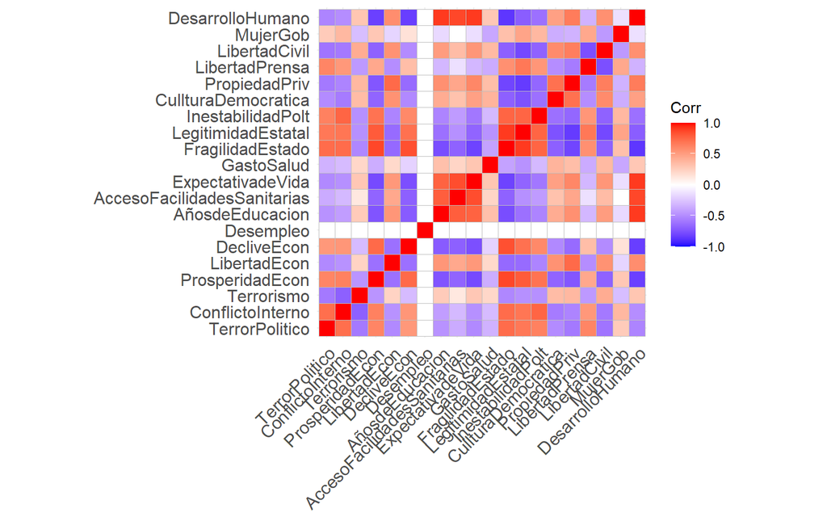

```r
library(ggcorrplot)
ggcorrplot(corMatrix,
           p.mat = cor_pmat(corMatrix),
           insig = "blank")
```

# **Prueba KMO**

```r
library(psych)
KMO(corMatrix)
```

```
## Kaiser-Meyer-Olkin factor adequacy
## Call: KMO(r = corMatrix)
## Overall MSA =  0.91
## MSA for each item =
##              TerrorPolitico            ConflictoInterno
##                        0.96                        0.91
##                  Terrorismo             ProsperidadEcon
##                        0.87                        0.97
##                LibertadEcon                 DecliveEcon
##                        0.91                        0.92
##                   Desempleo             AñosdeEducacion
##                        0.23                        0.88
## AccesoFacilidadesSanitarias           ExpectativadeVida
##                        0.93                        0.91
##                  GastoSalud            FragilidadEstado
##                        0.91                        0.91
##          LegitimidadEstatal           InestabilidadPolt
##                        0.92                        0.95
##         CullturaDemocratica               PropiedadPriv
##                        0.96                        0.92
##              LibertadPrensa               LibertadCivil
##                        0.90                        0.89
##                    MujerGob            DesarrolloHumano
##                        0.92                        0.87
```

**Interpretación**: según el Overall MSA, la matriz presentada es válida ya que obtiene un valor mayor a 0.5.

# **Prueba de Bartlett**

```r
cortest.bartlett(corMatrix,n=nrow(base1))$p.value>0.05
```

```
## [1] FALSE
```

**Interpretación**: la prueba de Barlett sale negativa, por tanto, la matriz de correlación realizada es válida y no es una matriz de identidad.

# **Contabilizando cuántos factores se utilizarán**

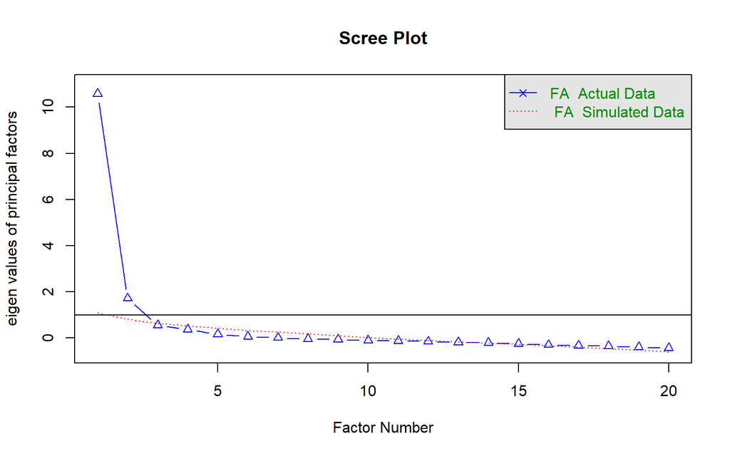

```
## Parallel analysis suggests that the number of factors =  2  and the number of components =  NA
```

```r
fa.parallel(corMatrix, fm="pa", fa="fa", main = "Scree Plot")
```

**Interpretación**: Según R, lo óptimo sería que se realice 2 grupos de factores.

## **Otra forma de calcular los factores**

```r
eigen<-eigen(cor(base1, use="complete"))
eigen$values
```

```
##  [1] 10.94711583  2.24242628  1.27267177  0.93663698  0.87380960  0.61307380
##  [7]  0.55947127  0.41880223  0.38025704  0.30879291  0.26843584  0.24830759
## [13]  0.23064588  0.19458694  0.13881363  0.13007258  0.09876581  0.08229712
## [19]  0.02944084  0.02557605
```

**Interpretación**: En la presente prueba se tiene que contar las dimensiones que posean valores mayores a 1 para saber cuántos factores realizar. Como se observa, solo hay 3 dimensiones con valores mayores a 1; por tanto, esta será la cantidad óptima final de factores ha crear.

# **Creación de los factores**

```r
library(GPArotation)
factorial <- fa(base1,nfactors = 3,rotate = "varimax",fm="minres")
```

## **Gráfico de factores**

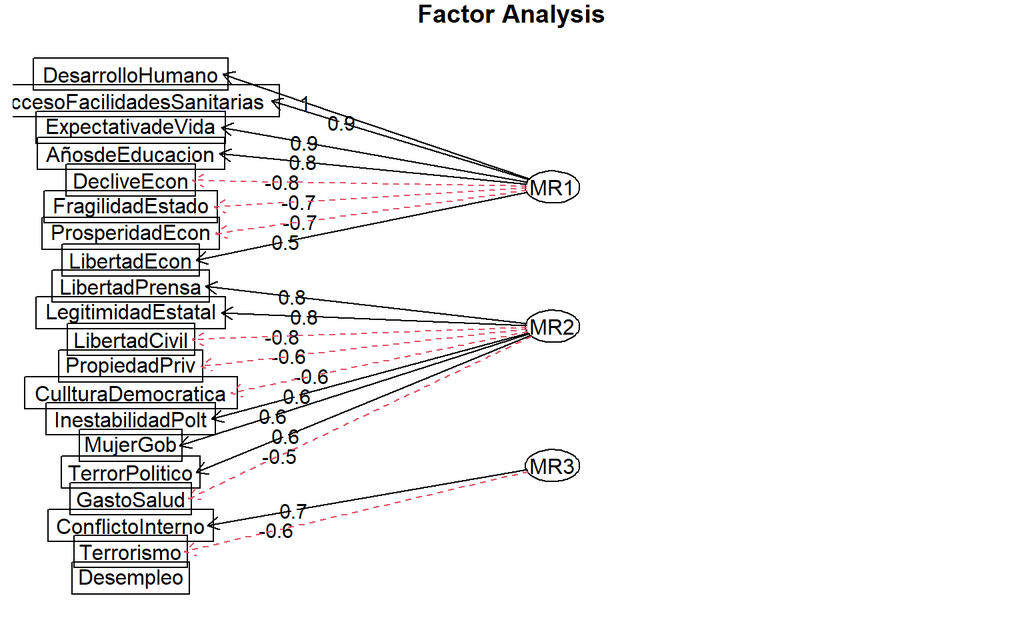

```r
fa.diagram(factorial)
```

# **Visualizando la composición de cada factor**

```r
print(factorial$loadings,cutoff = 0.5)
```

```
##
## Loadings:
##                             MR1    MR2    MR3
## TerrorPolitico                      0.563
## ConflictoInterno                    0.550  0.704
## Terrorismo                                -0.557
## ProsperidadEcon             -0.728
## LibertadEcon                 0.520
## DecliveEcon                 -0.783
## Desempleo
## AñosdeEducacion              0.834
## AccesoFacilidadesSanitarias  0.915
## ExpectativadeVida            0.872
## GastoSalud
## FragilidadEstado            -0.744  0.567
## LegitimidadEstatal          -0.536  0.785
## InestabilidadPolt                   0.581
## CullturaDemocratica                -0.632
## PropiedadPriv                0.543 -0.644
## LibertadPrensa                      0.806
## LibertadCivil                      -0.769
## MujerGob                            0.576
## DesarrolloHumano             0.955
##
##                  MR1   MR2   MR3
## SS loadings    6.543 5.387 1.487
## Proportion Var 0.327 0.269 0.074
## Cumulative Var 0.327 0.597 0.671
```

*3er factor*: Conflicto Interno, Terrorismo

# **Análisis comunalidad, complejidad y singularidad**

```r
sort(factorial$communality)
```

```
##                   Desempleo                  GastoSalud
##                  0.07596597                  0.24328732
##                    MujerGob                LibertadEcon
##                  0.33298190                  0.49755403
##                  Terrorismo         CullturaDemocratica
##                  0.51385410                  0.56128034
##              TerrorPolitico              LibertadPrensa
##                  0.64280942                  0.67318709
##           InestabilidadPolt               PropiedadPriv
##                  0.69072700                  0.71439318
##               LibertadCivil                 DecliveEcon
##                  0.73267956                  0.74226476
##             AñosdeEducacion             ProsperidadEcon
##                  0.75948444                  0.81911203
##           ExpectativadeVida AccesoFacilidadesSanitarias
##                  0.82926166                  0.83884380
##            ConflictoInterno          LegitimidadEstatal
##                  0.89268584                  0.92356164
##            FragilidadEstado            DesarrolloHumano
##                  0.95679700                  0.97643156
```

**Interpretación**: La variable “Desarrollo Humano” tiene mayor porcentaje de varianza común. Es decir, es la variable que es más común en los componentes.

```r
sort(factorial$complexity)
```

```
## AccesoFacilidadesSanitarias                    MujerGob
##                    1.002893                    1.006394
##              LibertadPrensa            DesarrolloHumano
##                    1.071912                    1.142724
##             AñosdeEducacion           ExpectativadeVida
##                    1.180394                    1.183987
##                   Desempleo                  GastoSalud
##                    1.243519                    1.356837
##                 DecliveEcon               LibertadCivil
##                    1.435743                    1.459187
##         CullturaDemocratica          LegitimidadEstatal
##                    1.742492                    1.847494
##               PropiedadPriv             ProsperidadEcon
##                    1.968691                    1.978848
##                  Terrorismo                LibertadEcon
##                    2.006566                    2.015957
##            FragilidadEstado            ConflictoInterno
##                    2.202812                    2.300540
##           InestabilidadPolt              TerrorPolitico
##                    2.669970                    2.670202
```

**Interpretación**: “TerrorPolitico” es la variable que ha aportado a muchos componentes.

```r
sort(factorial$uniquenesses)
```

```
##            DesarrolloHumano            FragilidadEstado
##                  0.02356844                  0.04320300
##          LegitimidadEstatal            ConflictoInterno
##                  0.07643836                  0.10731416
## AccesoFacilidadesSanitarias           ExpectativadeVida
##                  0.16115620                  0.17073834
##             ProsperidadEcon             AñosdeEducacion
##                  0.18088797                  0.24051556
##                 DecliveEcon               LibertadCivil
##                  0.25773524                  0.26732044
##               PropiedadPriv           InestabilidadPolt
##                  0.28560682                  0.30927300
##              LibertadPrensa              TerrorPolitico
##                  0.32681291                  0.35719058
##         CullturaDemocratica                  Terrorismo
##                  0.43871966                  0.48614590
##                LibertadEcon                    MujerGob
##                  0.50244597                  0.66701810
##                  GastoSalud                   Desempleo
##                  0.75671268                  0.92403403
```

**Interpretación**: “Desempleo” es la variable que tiene un factor único más grande.

## **Agreango los factores al subset**

```r
#Creando un dataset
factorial_casos<-as.data.frame(factorial$scores)
head(factorial_casos)
```

```
##                    MR1        MR2         MR3
## Afghanistan -1.1391134  0.6411979  1.49637452
## Albania      0.2937383  0.2023397 -1.22908108
## Algeria      0.4843707  0.8798477  0.41946602
## Angola      -0.9636161  0.6640114 -0.72028970
## Argentina    0.9206324 -0.1149823 -0.01038645
## Armenia      0.1291985  0.2676414 -0.11793876
```

```r
summary(factorial_casos)
```

```
##       MR1               MR2                 MR3
##  Min.   :-2.2418   Min.   :-2.052186   Min.   :-2.25198
##  1st Qu.:-0.7997   1st Qu.:-0.675605   1st Qu.:-0.53912
##  Median : 0.2628   Median :-0.002037   Median :-0.03816
##  Mean   : 0.0000   Mean   : 0.000000   Mean   : 0.00000
##  3rd Qu.: 0.8320   3rd Qu.: 0.654331   3rd Qu.: 0.45534
##  Max.   : 1.6656   Max.   : 2.441482   Max.   : 2.86288
```

```r
#Agregándolas al subset
base1$DesarrolloEconómicoyHumano <- factorial_casos$MR1
base1$InestabilidadPoltyDemocracia<- factorial_casos$MR2
base1$InseguridadyPazEstatal<- factorial_casos$MR3
```

## **Estandarizando e inspeccionando las nuevas variables latentes**

```r
library(BBmisc)
base1$DesarrolloEconómicoyHumano = normalize(base1$DesarrolloEconómicoyHumano,
                                        method = "range",
                                        margin=2, # by column
                                        range = c(0, 100))

summary(base1$DesarrolloEconómicoyHumano)
```

```
##    Min. 1st Qu.  Median    Mean 3rd Qu.    Max.
##    0.00   36.91   64.10   57.37   78.67  100.00
```

https://www.es.amnesty.org/en-que-estamos/blog/historia/articulo/la-pobreza-tiene-genero/

```r
base1$InestabilidadPoltyDemocracia = normalize(base1$InestabilidadPoltyDemocracia,
                                        method = "range",
                                        margin=2, # by column
                                        range = c(0, 100))

summary(base1$InestabilidadPoltyDemocracia)
```

```
##    Min. 1st Qu.  Median    Mean 3rd Qu.    Max.
##    0.00   30.63   45.62   45.67   60.23  100.00
```

```r
base1$IneguridadyPazEstatal = normalize(base1$InseguridadyPazEstatal,
                                        method = "range",
                                        margin=2, # by column
                                        range = c(0, 100))

summary(base1$InseguridadyPazEstatal)
```

```
##     Min.  1st Qu.   Median     Mean  3rd Qu.     Max.
## -2.25198 -0.53912 -0.03816  0.00000  0.45534  2.86288
```

https://oxfamilibrary.openrepository.com/bitstream/handle/10546/620690/bp-women-in-conflict-zones-290319-es.pdf

https://www.unwomen.org/es/news/in-focus/end-violence-against-women/2014/conflict

# **Modelo de regresión ordinal**

(*)Ya que en el presente trabajo queremos hallar el nivel de desigualdad de género y su correlación con los niveles de desarrollo económico y humano, regímenes políticos democráticos, y seguridad y paz estatal; consideramos necesario, para un mejor análisis, convertir el índice de desigualdad de género de nuestra base de datos en una variable ordinal. De esta manera, se podrá hacer una mejor interpretación de los resultados del modelo de regresión y ver una clasificación según niveles de desigualdad de los países. Por ello, nuestra variable dependiente será convertida a una escala del 0 al 100 y luego será dividida en 4: muy baja desigualdad de género, baja desigualdad de género, alta desigualdad de género y muy alta desigualdad de género.

## **Alistando la variable dependiente**

```r
#Agregando la Variable Dependiente al subset
base1$DesigualdadGenero = base$GII2015

#Quitándole NAs
base1$DesigualdadGenero[is.na(base1$DesigualdadGenero)] <- mean(base1$DesigualdadGenero,na.rm=TRUE)

#Estandarizando para hacer más fácil el análisis
base1$DesigualdadGenero = normalize(base1$DesigualdadGenero,
                                        method = "range",
                                        margin=2, # by column
                                        range = c(0, 100))

#Recodificando la variable dependiente
base1$Desigualdad_ord = cut(base1$DesigualdadGenero, breaks = c(0,10,40,70,100), include.lowest = T, ordered_result = T, labels = c("Muy Baja Desigualdad de Género", "Baja Desigualdad de Género","Alta Desigualdad de Género", "Muy Alta Desigualdad de Género"))
table(base1$Desigualdad_ord)
```

```
##
## Muy Baja Desigualdad de Género     Baja Desigualdad de Género
##                             20                             49
##     Alta Desigualdad de Género Muy Alta Desigualdad de Género
##                             80                             27
```

#**Modelo**

```r
library(MASS)
modelo <- polr(Desigualdad_ord ~ DesarrolloEconómicoyHumano + InestabilidadPoltyDemocracia + InseguridadyPazEstatal, data = base1, Hess=T)
summary(modelo)
```

```
## Call:
## polr(formula = Desigualdad_ord ~ DesarrolloEconómicoyHumano +
##     InestabilidadPoltyDemocracia + InseguridadyPazEstatal, data = base1,
##     Hess = T)
##
## Coefficients:
##                                 Value Std. Error t value
## DesarrolloEconómicoyHumano   -0.12875    0.01442  -8.928
## InestabilidadPoltyDemocracia  0.05092    0.00965   5.276
## InseguridadyPazEstatal        0.29391    0.19440   1.512
##
## Intercepts:
##                                                           Value   Std. Error
## Muy Baja Desigualdad de Género|Baja Desigualdad de Género -9.9946  1.1699
## Baja Desigualdad de Género|Alta Desigualdad de Género     -6.2161  0.9574
## Alta Desigualdad de Género|Muy Alta Desigualdad de Género -0.7016  0.5801
##                                                           t value
## Muy Baja Desigualdad de Género|Baja Desigualdad de Género -8.5427
## Baja Desigualdad de Género|Alta Desigualdad de Género     -6.4925
## Alta Desigualdad de Género|Muy Alta Desigualdad de Género -1.2094
##
## Residual Deviance: 234.8896
## AIC: 246.8896
```

## **a. Sacando el p-value**

## **i. Sacando el t-value**

```r
summary_table <- coef(summary(modelo))
summary_table
```

```
##                                                                 Value
## DesarrolloEconómicoyHumano                                -0.12874678
## InestabilidadPoltyDemocracia                               0.05091723
## InseguridadyPazEstatal                                     0.29391262
## Muy Baja Desigualdad de Género|Baja Desigualdad de Género -9.99455210
## Baja Desigualdad de Género|Alta Desigualdad de Género     -6.21606231
## Alta Desigualdad de Género|Muy Alta Desigualdad de Género -0.70157650
##                                                           Std. Error   t value
## DesarrolloEconómicoyHumano                                0.01441997 -8.928370
## InestabilidadPoltyDemocracia                              0.00965001  5.276391
## InseguridadyPazEstatal                                    0.19440320  1.511871
## Muy Baja Desigualdad de Género|Baja Desigualdad de Género 1.16994688 -8.542740
## Baja Desigualdad de Género|Alta Desigualdad de Género     0.95742719 -6.492465
## Alta Desigualdad de Género|Muy Alta Desigualdad de Género 0.58010345 -1.209399
```

## **ii. Creando el objeto del p-value**

```r
pval <- pnorm(abs(summary_table[, "t value"]),lower.tail = FALSE)* 2
pval
```

```
##                                DesarrolloEconómicoyHumano
##                                              4.323333e-19
##                              InestabilidadPoltyDemocracia
##                                              1.317526e-07
##                                    InseguridadyPazEstatal
##                                              1.305666e-01
## Muy Baja Desigualdad de Género|Baja Desigualdad de Género
##                                              1.310760e-17
##     Baja Desigualdad de Género|Alta Desigualdad de Género
##                                              8.444329e-11
## Alta Desigualdad de Género|Muy Alta Desigualdad de Género
##                                              2.265096e-01
```

## **iii. Agregando el p-value a la tabla**

```r
summary_table <- cbind(summary_table, "p value" = pval)
summary_table
```

```
##                                                                 Value
## DesarrolloEconómicoyHumano                                -0.12874678
## InestabilidadPoltyDemocracia                               0.05091723
## InseguridadyPazEstatal                                     0.29391262
## Muy Baja Desigualdad de Género|Baja Desigualdad de Género -9.99455210
## Baja Desigualdad de Género|Alta Desigualdad de Género     -6.21606231
## Alta Desigualdad de Género|Muy Alta Desigualdad de Género -0.70157650
##                                                           Std. Error   t value
## DesarrolloEconómicoyHumano                                0.01441997 -8.928370
## InestabilidadPoltyDemocracia                              0.00965001  5.276391
## InseguridadyPazEstatal                                    0.19440320  1.511871
## Muy Baja Desigualdad de Género|Baja Desigualdad de Género 1.16994688 -8.542740
## Baja Desigualdad de Género|Alta Desigualdad de Género     0.95742719 -6.492465
## Alta Desigualdad de Género|Muy Alta Desigualdad de Género 0.58010345 -1.209399
##                                                                p value
## DesarrolloEconómicoyHumano                                4.323333e-19
## InestabilidadPoltyDemocracia                              1.317526e-07
## InseguridadyPazEstatal                                    1.305666e-01
## Muy Baja Desigualdad de Género|Baja Desigualdad de Género 1.310760e-17
## Baja Desigualdad de Género|Alta Desigualdad de Género     8.444329e-11
## Alta Desigualdad de Género|Muy Alta Desigualdad de Género 2.265096e-01
```

# **Calculando e interpretando coeficientes**

```r
exp(coef(modelo))
```

```
##   DesarrolloEconómicoyHumano InestabilidadPoltyDemocracia
##                    0.8791966                    1.0522358
##       InseguridadyPazEstatal
##                    1.3416667
```

## **a) Interpretación de VI - Economía y Desarrollo humano:**

```r
(1-0.8791966)*100
```

```
## [1] 12.08034
```

**Interpretación**: si es que el porcentaje de economía y desarrollo humano de un país aumenta en 1, entonces la desigualdad de género disminuye 12.08%.

## **b) Interpretación de VI - Inestabilidad Política y Democracia:**

```r
(1.0522358 - 1)*100
```

```
## [1] 5.22358
```

**Interpretación**: si es que el porcentaje de Inestabilidad Política y Democracia aumenta en 1, entonces la desigualdad de género aumenta en 5.2%.

```r
(1.3416667 - 1)*100
```

```
## [1] 34.16667
```

# *R2 del modelo*

```r
library(DescTools)
PseudoR2(modelo, which = c("Nagelkerke"))
```

```
## Nagelkerke
##  0.7492537
```

# **Mapa**

Agregando el isocode al subset

```r
base1$isocod = base$cod
```

```r
library(ggplot2)
library(rworldmap)
library(rgdal)
joinData <- joinCountryData2Map( base1,
                                 joinCode = "ISO_A3",
                                 nameJoinColumn = "isocod")
```

```
## 173 codes from your data successfully matched countries in the map
## 3 codes from your data failed to match with a country code in the map
## 70 codes from the map weren't represented in your data
```

## **Ejecutando mapa**

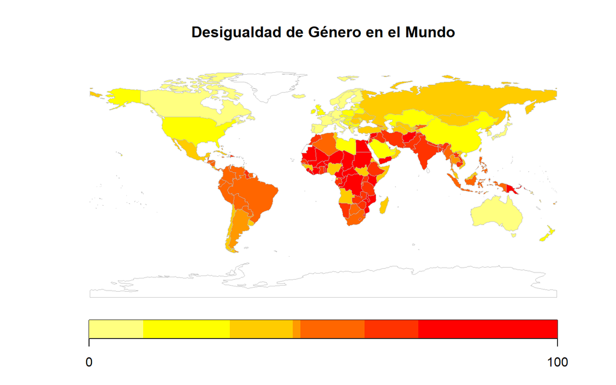

```r
theMap <- mapCountryData( joinData, nameColumnToPlot="DesigualdadGenero",mapTitle="Desigualdad de Género en el Mundo", addLegend=TRUE )
```

# **Hallazgos**

De manera general, se puede decir que luego del presente análisis estadístico se obtuvo que el nivel de desigualdad de género en un determinado país es influenciado por variables que están relacionadas a la estabilidad de un gobierno, características de un Estado y al Desarrollo Humano. Los países que tienen un régimen de gobierno más democrático y estable, presentaron una menor desigualdad. Estos se encuentran especialmente en los países del hemisferio Norte y Oceanía como Finlandia, Nueva Zelanda, Noruega, entre otros. Mientras que los Estados del continente africano y del medio oriente fueron los que presentaron mayores niveles de desigualdad. Asimismo, a partir del análisis también se logró encontrar los siguientes hallazgos:

En cuanto a los niveles de desigualdad de género en el mundo, se encontró que la mayoría de países (107) presentan una alta y muy alta desigualdad de género. Siendo 80 países que encajan en la primera clasificación y 27, en la segunda. Por el contrario, sólo 20 países de los 176 de la muestra poseen una muy baja desigualdad de género. De esta manera, se puede observar que esta problemática sigue siendo un punto pendiente en la agenda de muchos países que debe ser arreglado para poder garantizar el respeto por los derechos de las mujeres y su libre desarrollo. Los países del hemisferio norte y del continente de Oceanía (Nueva Zelanda, Australia, etc.), son los que más destacan por poseer muy bajos o bajos niveles de desigualdad de género. En el caso de Latinoamérica y Centroamérica se identificó que poseen niveles altos de desigualdad de género sobre todo países como Bolivia, Perú, Venezuela, Ecuador, Colombia y Brasil. Asimismo, a comparación del resto de Europa, que posee niveles bajos o muy bajos de desigualdad, Rusia posee un nivel alto. Finalmente, el continente que posee los niveles más altos de desigualdad son el de África y Medio Oriente. Como se ha mencionado, los países de este continente presentan características inestables con un alto nivel de inseguridad y violencia que ponen en vulnerabilidad la protección de los derechos de las mujeres.

Por último, gracias a los hallazgos encontrados podemos identificar qué escenarios son los que exponen y facilitan que en las sociedades de hoy se desarrollen altos índices de desigualdad de género. Así, como se ha podido observar, contextos de violencia estatal y de constante inseguridad, gobiernos con bajos valores democráticos y con características que perjudican al nivel de Desarrollo Humano como poca libertad económica o la falta de educación, entre otros, son los que han presentado mayores niveles de desigualdad en el mundo. De esta manera, se puede decir que la igualdad de género no es un problema independiente a las dinámicas que ocurren dentro de un Estado y el comportamiento de este. Por el contrario, el Estado al ser el principal responsable sobre la protección de los derechos humanos de sus ciudadanos, debe brindar el marco ideal para que estos puedan hacer un goce adecuado de sus libertades y derechos. Sin embargo, como se ha mencionado anteriormente, si un país se encuentra en constantes crisis tanto políticas como económicas, no proporciona servicios básicos y fomenta la libertad económica, y presenta conflictos que ponen en riesgo la seguridad de las personas, será casi imposible que las mujeres y el resto de ciudadanos puedan desarrollar un proyecto de vida con libertad que le permitan hacer uso de sus derechos fundamentales.

# **Conclusiones**

Es innegable la realidad que vivimos las mujeres producto de la desigualdad de género, desde no poder ascender a puestos más altos en el trabajo o ni siquiera lograr terminar nuestra educación por tener que cumplir estereotipos que nos encierran en la esfera privada. Si bien, hay muchos países que en esta materia han logrado sustanciales cambios y mantienen una sociedad en donde todos tienen las mismas oportunidades y los mismos derechos, aún queda un largo camino por recorrer. Es alarmante ver las cifras ofrecidas por distintas organizaciones que reflejan esta dura realidad, por ello, es determinante enfocarnos en las soluciones para lograr erradicar los problemas de género en el mundo. Bajo esta línea consideramos que el trabajo expuesto ha sido una forma de ayudar a empezar a identificar qué escenarios y circunstancias afectan a los niveles de desigualdad en el mundo. Para que, de esta manera, se pueda trabajar en ello desde el ámbito estatal y social. Asimismo, sostenemos que el análisis presentado y los factores encontrados aportarán para las investigaciones en torno a las causas de la desigualdad de un determinado país ya que, como se ha podido observar, nuestra data presenta los resultados de 176 países de todos los continentes; por lo que, sería de gran ayuda para poder analizar cómo vamos en estos temas a nivel global o regional.

Si bien el fenómeno de la desigualdad de género es uno amplio que para poder entenderlo se necesita abarcar diferentes puntos de nuestra sociedad y el Estado, creemos que el presente análisis ha logrado evidenciar, desde una perspectiva más estatal, los factores que lograrían explicar el porqué de las diferencias en los niveles de desigualdad en el mundo. Sin embargo, es importante ser conscientes que este tipo de problemáticas que afectan a las mujeres, deben ser analizadas tomando en cuenta una perspectiva integral por lo que no se puede afirmar que sólo los factores representados explicarían por completo dicho fenómeno. Encontrar factores que provengan desde la sociedad como los estereotipos de género por ejemplo o la tolerancia que las personas tienen frente la violencia de género, también sería de gran ayuda para lograr entender por qué en ciertos países hay más igualdad que otros. Por ello, apostamos por análisis estadísticos que puedan ofrecernos evidencia empírica de lo mencionado, proporcionando escalas de medición por ejemplo a estas percepciones de la sociedad. La suma de todo ello será de gran utilidad para poder identificar los elementos a eliminar en nuestra sociedad para un futuro mejor en donde todas y todos crezcamos en igualdad de condiciones.

# **Bibliografía**

BBC Mundo (2016). Mariana Martinez: “Barómetro económico: la mujer y la desigualdad” http://news.bbc.co.uk/hi/spanish/business/barometro_economico/newsid_4754000/4754380.stm

Caprioli, M (2000). “Gendered Conflict.” Journal of Peace Research 37: 51–68. ——. “Gender Equality and State Aggression: The Impact of Domestic Gender Equality on State First Use of Force.” International Interactions 29, no. 3 (2003): 195–214.

HUDSON, V. M., BOWEN, D. L., & NIELSEN, P. L. (2020). The First Political Order: How Sex Shapes Governance and National Security Worldwide. Columbia University Press. http://www.jstor.org/stable/10.7312/huds19466

Mones, B (2004). “La inclusión de las mujeres y la igualdad de género: nuevos desafíos para la modernización del Estado” en IX Congreso Internacional del CLAD sobre la Reforma del Estado y de la Administración Pública, Madrid, España, 2 – 5 Nov. 2004 http://americalatinagenera.org/newsite/images/cdr-documents/publicaciones/doc_444_0050134.pdf

Mukhopadhyay, M (2007). Justicia de género, ciudadanía y desarrollo. Centro Internacional de Investigaciones para el desarrollo. Tercera Edición, India, New Delhi. https://idl-bnc-idrc.dspacedirect.org/handle/10625/34957

Sahui, M (2015). La igualdad en la medida de la calidad democrática - Una revisión crítica de la propuesta de Leonardo Morlino. Revista Dossier - 7 de mayo de 2015: pp. 33 - 55 https://www.redalyc.org/pdf/421/42146505010.pdf

The WomanStatsProject (2019). Base de Datos sobre la situación de la mujer 2019. Brigham Young College, Utah. Revisado: 21 de agosto 2021 https://www.womanstats.org/new/ Wood, Reed, and Mark Ramirez (2018). “Exploring the Microfoundations of the Gender Equality Peace Hypothesis.” International Studies Review 20, no. 3: 345–367. https://doi.org /10.1093/isr/vix016.

World Economic Forum (2020). Global Gender Gap Report : “Informe Final de la brecha de desigualdad de género en el mundo 2020”. Revisado: 3 de setiembre 2021 https://www.weforum.org/reports/gender-gap-2020-report-100-years-pay-equality

Watkins, M . (2020). A Step-by-Step Guide to Exploratory Factor Analysis with R and RStudio. pp. 74-122